# Data Analysis Skill Test - Analyst Regional Economics

##### - Exports Corn by state - USD

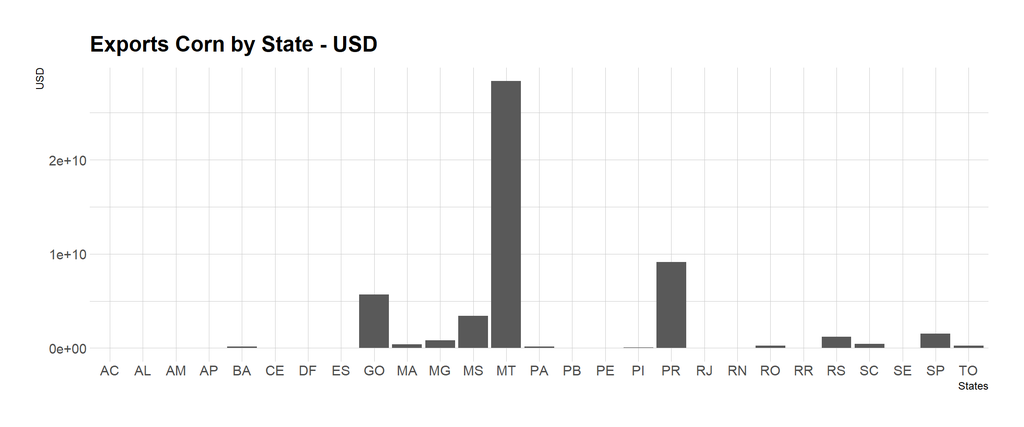

```r
corn_states_usd = data.frame(0)
for (i in 1:27) {
  corn_states_usd[i,] = export_br_state_usd[i,]
}
corn_states_usd = cbind(corn_states_usd, states)
colnames(corn_states_usd) = c("usd","state")

graph_corn_state_usd = ggplot(corn_states_usd, aes(x=states, y=usd))+
  geom_bar(stat = "identity")+
  theme_ipsum()+
  ggtitle("Exports Corn by State - USD")+
  xlab("States")+
  ylab("USD")
graph_corn_state_usd
```

The exports of corn in terms of uSD has the same configuration of the corns exports in terms of tons.

##### - Exports Soybean_meal by state - USD

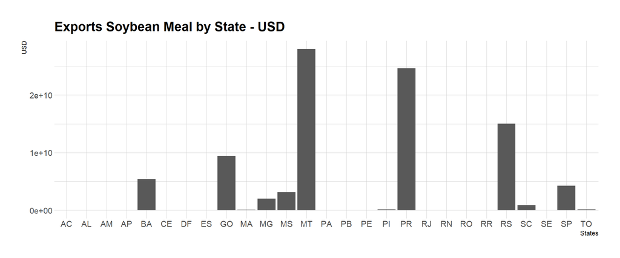

```r
soybean_meal_states_usd = data.frame(0)
for (i in 1:27) {
  soybean_meal_states_usd[i,] = export_br_state_usd[i+27,] ### Sempre somar mais 27
}
soybean_meal_states_usd = cbind(soybean_meal_states_usd, states)
colnames(soybean_meal_states_usd) = c("usd","state")

graph_soybean_meal_state_usd = ggplot(soybean_meal_states_usd, aes(x=states, y=usd))+
  geom_bar(stat = "identity")+
  theme_ipsum()+
  ggtitle("Exports Soybean Meal by State - USD")+
  xlab("States")+
  ylab("USD")
graph_soybean_meal_state_usd
```

In terms of USD, the soybean meal exports by state has MT how the main seller. The exports in tons, the most important state is PR, but in USD is MT. This means that in the MT, the price of soybean meal is bigger than the price of this commodity in PR.

##### - Exports Soybean_oil by state - USD

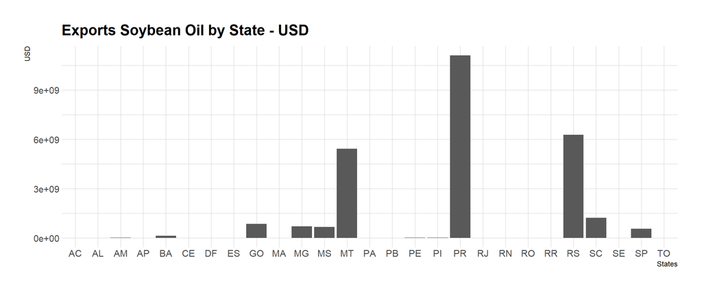

```r
soybean_oil_states_usd = data.frame(0)
for (i in 1:27) {
  soybean_oil_states_usd[i,] = export_br_state_usd[i+54,] ### Sempre somar mais 27
}
soybean_oil_states_usd = cbind(soybean_oil_states_usd, states)
colnames(soybean_oil_states_usd) = c("usd","state")

graph_soybean_oil_state_usd = ggplot(soybean_oil_states_usd, aes(x=states, y=usd))+
  geom_bar(stat = "identity")+
  theme_ipsum()+
  ggtitle("Exports Soybean Oil by State - USD")+
  xlab("States")+
  ylab("USD")
graph_soybean_oil_state_usd
```

The most important states in terms of soybean oil exports, measured in USD, are the same when we measure in tons.

##### - Exports Soybeans by state - USD

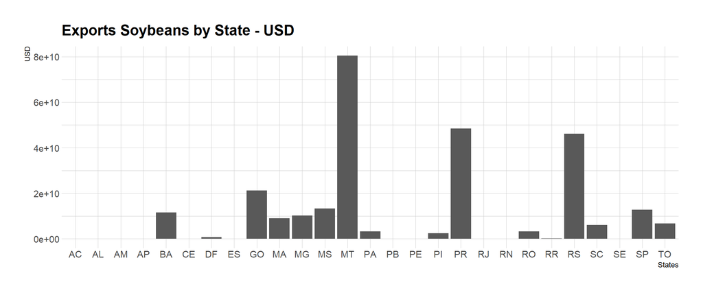

```r
soybeans_states_usd = data.frame(0)
for (i in 1:27) {
  soybeans_states_usd[i,] = export_br_state_usd[i+81,] ### Sempre somar mais 27
}
soybeans_states_usd = cbind(soybeans_states_usd, states)
colnames(soybeans_states_usd) = c("usd","state")

graph_soybeans_state_usd = ggplot(soybeans_states_usd, aes(x=states, y=usd))+
  geom_bar(stat = "identity")+
  theme_ipsum()+
  ggtitle("Exports Soybeans by State - USD")+
  xlab("States")+
  ylab("USD")
graph_soybeans_state_usd
```

The most important states in terms of soybeans exports are, measured in USD: MT, PR, RS, GO and MT.

##### - Exports Sugar by state - USD

[figure not shown]

```r
sugar_states_usd = data.frame(0)
for (i in 1:27) {
  sugar_states_usd[i,] = export_br_state_usd[i+27,] ### Sempre somar mais 27
}
sugar_states_usd = cbind(sugar_states_usd, states)
colnames(sugar_states_usd) = c("usd","state")

graph_sugar_state_usd = ggplot(sugar_states_usd, aes(x=states, y=usd))+
  geom_bar(stat = "identity")+
  theme_ipsum()+
  ggtitle("Exports Sugar by State - USD")+
  xlab("States")+
  ylab("usd")
graph_sugar_state_usd
```

[output not shown]

##### - Exports Wheat by state - USD

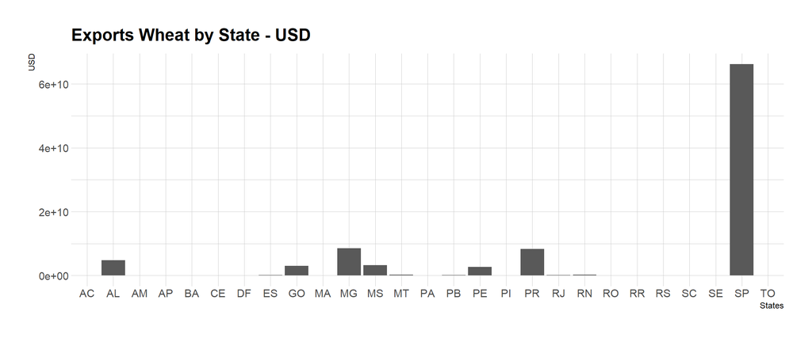

```r
Wheat_states_usd = data.frame(0)
for (i in 1:27) {
  Wheat_states_usd[i,] = export_br_state_usd[i+108,] ### Sempre somar mais 27
}
Wheat_states_usd = cbind(Wheat_states_usd, states)
colnames(Wheat_states_usd) = c("usd","state")

graph_Wheat_state_usd = ggplot(Wheat_states_usd, aes(x=states, y=usd))+
  geom_bar(stat = "identity")+
  theme_ipsum()+
  ggtitle("Exports Wheat by State - USD")+
  xlab("States")+
  ylab("USD")
graph_Wheat_state_usd
```

##### 6. Now, we ask you to show your modelling skills. Feel free to use any type of modelling approach, but bear in mind that the modelling approach depends on the nature of your data, and so different models yield different estimates and forecasts. To help you out in this task we also provide you with a dataset of possible covariates (.xlsx). They all come from public sources (IMF, World Bank) and are presented in index number format. Question: What should be the total brazilian soybeans, soybean_meal, and corn export forecasts, in tons, for the next 11 years (2020-2030)? We’re mostly interested in the annual forecast.

##### - First, save de dataset “covariates.xlsx” as “covariates.csv”. After this, open the file.

```r
covariates <- read_delim("C:/Users/rezen/OneDrive/Documentos/4intelligence/covariates.csv",
                         ";", escape_double = FALSE, trim_ws = TRUE)

mes=c("01","02","03","04","05","06","07","08","09","10","11","12")
year = seq(1997, 2019, 1) ### year
year = as.character(year)


list_comex_br_product = list()
list_comex_br = list()
for (k in 1:length(products)) {

  for (j in 1:length(year)) {
    for (i in 1:length(mes)) {
      list_comex_br_product[[i+(length(mes)*(j-1))]] = data_comexstat %>%
        select(date, product, state, country, type, route, tons, usd) %>%
        filter(date==paste(year[j], mes[i], "01", sep="-"), product==products[k], type=='Export')
    }
  }
  list_comex_br[[k]]=list_comex_br_product
}
```

We want to estimate the country demand by soybeans, soybean meal and corn between 2020 – 2030. To do this, first we change the number format of dataset variables “data_comexstat.csv” to index number format, so that, these data are compare with the data from the other database, “covariates.csv”. After this, we select to 1997-2030 observations in the “covariates.csv” to change the base period index number to 1997. In the database “data_comexstat.csv” we do the variables forecast until 2030. The next step is calculating the variation of tons, prices and GDP to do the elasticity. The elasticity is calculating by dividing the soybeans, soybean meal and corn variation tons by the variation prices. The GDP variation represents the GDP growth. Multiplying the elasticity by GDP growth we get the forecast Country and World Demand of soybeans, soybean meal and corn exports.

##### - Variables by tons

```r
export_br = list()
for (j in 1:length(products)) {
  export_br_aux = data.frame()
  x = list_comex_br[[j]]
  for (i in 1:length(list_comex_br[[j]])) {
    export_br_aux = rbind(export_br_aux, sum(x[[i]]$tons))
  }
  export_br[[j]]=export_br_aux
}

data_export = data.frame()
for (j in 1:length(year)) {
  for (i in  1:length(mes)) {
    data_export = rbind(data_export, paste(year[j], mes[i], "01", sep="-"))
  }
}

for (i in 1:length(products)) {
  export_br[[i]] = cbind(data_export, export_br[[i]])
  export_br[[i]] = cbind(export_br[[i]], rep(products[i],276))
  colnames(export_br[[i]]) = c("date","sum_tons","product")
  export_br[[i]]$date = as.Date(export_br[[i]]$date)
}


products_year_tons = data.frame()
for (j in 1:6) {
  for (i in 1:23) {
    products_year_tons[i,j] = sum(export_br[[j]]$sum_tons[(12*(i-1)+1):(i*12)])
  }
}
colnames(products_year_tons) = paste(products, "_tons_year")
```

##### - Variables by usd

```r
export_br = list()
for (j in 1:length(products)) {
  export_br_aux = data.frame()
  x = list_comex_br[[j]]
  for (i in 1:length(list_comex_br[[j]])) {
    export_br_aux = rbind(export_br_aux, sum(x[[i]]$usd))
  }
  export_br[[j]]=export_br_aux
}

data_export = data.frame()
for (j in 1:length(year)) {
  for (i in  1:length(mes)) {
    data_export = rbind(data_export, paste(year[j], mes[i], "01", sep="-"))
  }
}

for (i in 1:length(products)) {
  export_br[[i]] = cbind(data_export, export_br[[i]])
  export_br[[i]] = cbind(export_br[[i]], rep(products[i],276))
  colnames(export_br[[i]]) = c("date","sum_usd","product")
  export_br[[i]]$date = as.Date(export_br[[i]]$date)
}


products_year_usd = data.frame()
for (j in 1:6) {
  for (i in 1:23) {
    products_year_usd[i,j] = sum(export_br[[1]]$sum_usd[(12*(i-1)+1):(i*12)])
  }
}

colnames(products_year_usd) = paste(products, "_usd_year")
```

##### - Products by year - TONS and USD

```r
data_year = cbind(year,products_year_tons, products_year_usd)
```

##### - Transform variable values of dataset “data_comexstat.csv” to Index number

```r
for (i in 2:length(data_year[1,])) {
  data_year[,i] = data_year[,i]/data_year[1,i]*100
}
```

##### - Select 1997 to 2030 Observations of “covariates.csv”

```r
covariates_1997_2030 = data.frame()
covariates_1997_2030 = covariates %>%
    select(colnames(covariates)) %>%
    filter(year>="1997")
covariates_1997_2030 = as.data.frame(covariates_1997_2030)
```

##### - Change the base period index number at dataset “covariates.csv” to 1997

```r
for (i in 2:13) {
  covariates_1997_2030[,i] = covariates_1997_2030[,i]/covariates_1997_2030[1,i]*100
}
```